# NYC 2021 Shootings

P. Chen

2026-04-07

## Introduction

This report looks at NYPD shooting incidents in 2021 and focuses on a few main questions: which boroughs had the most shootings, what time of day shootings were most common, where they tended to happen, and which demographic patterns appeared most often in the available records.

```r
required_packages <- c(
  "dplyr", "ggplot2", "readr", "stringr",
  "tidyr", "tibble", "knitr", "scales"
)
missing_packages <- required_packages[
  !vapply(required_packages, requireNamespace, logical(1), quietly = TRUE)
]

if (length(missing_packages) > 0) {
  install.packages(missing_packages, repos = "https://cloud.r-project.org")
}

invisible(lapply(required_packages, library, character.only = TRUE))
```

```r
refresh_data <- FALSE

snapshot_path <- file.path("data", "nyc_2021_shootings_2021.csv")

api_url <- paste0(
  "https://data.cityofnewyork.us/resource/833y-fsy8.csv?",
  "$limit=50000&",
  "$where=occur_date%20between%20%272021-01-01T00:00:00%27%20and%20%272021-12-31T23:59:59%27"
)

if (!dir.exists(dirname(snapshot_path))) {
  dir.create(dirname(snapshot_path), recursive = TRUE)
}

if (!file.exists(snapshot_path) || isTRUE(refresh_data)) {
  download.file(api_url, destfile = snapshot_path, mode = "wb", quiet = TRUE)
}

shootings_raw <- readr::read_csv(snapshot_path, show_col_types = FALSE)
```

## Data Overview

The dataset contains 2,011 shooting incidents from 2021. It includes the date, time, borough, reported location type, and demographic fields for victims and perpetrators when that information was available.

```r
shootings <- shootings_raw %>%
  mutate(
    occur_date = as.Date(occur_date),
    year = as.integer(format(occur_date, "%Y")),
    month = as.integer(format(occur_date, "%m")),
    hour = as.integer(substr(occur_time, 1, 2)),
    boro = stringr::str_to_title(boro),
    location_desc = na_if(location_desc, ""),
    perp_age_group = na_if(perp_age_group, ""),
    perp_sex = na_if(perp_sex, ""),
    perp_race = na_if(perp_race, ""),
    vic_age_group = na_if(vic_age_group, ""),
    vic_sex = na_if(vic_sex, ""),
    vic_race = na_if(vic_race, "")
  )

summary_table <- tibble::tibble(
  metric = c("Rows", "Columns", "Date range"),
  value = c(
    nrow(shootings),
    ncol(shootings),
    paste(min(shootings$occur_date), "to", max(shootings$occur_date))
  )
)

knitr::kable(summary_table)
```

| metric | value |
| --- | --- |
| Rows | 2011 |
| Columns | 24 |
| Date range | 2021-01-01 to 2021-12-31 |

```r
dplyr::glimpse(shootings)
```

```
## Rows: 2,011
## Columns: 24
## $ incident_key            <dbl> 238487793, 238490103, 238481445, 238481446, 23…
## $ occur_date              <date> 2021-12-31, 2021-12-31, 2021-12-31, 2021-12-3…
## $ occur_time              <time> 15:36:00, 19:23:00, 04:25:00, 04:00:00, 01:05…
## $ boro                    <chr> "Brooklyn", "Staten Island", "Brooklyn", "Bron…
## $ loc_of_occur_desc       <lgl> NA, NA, NA, NA, NA, NA, NA, NA, NA, NA, NA, NA…
## $ precinct                <dbl> 75, 120, 70, 40, 25, 32, 112, 49, 48, 43, 115,…
## $ jurisdiction_code       <dbl> 2, 0, 0, 2, 2, 0, 0, 0, 0, 0, 0, 0, 2, 2, 0, 0…
## $ loc_classfctn_desc      <lgl> NA, NA, NA, NA, NA, NA, NA, NA, NA, NA, NA, NA…
## $ location_desc           <chr> "MULTI DWELL - PUBLIC HOUS", "PVT HOUSE", NA, …
## $ statistical_murder_flag <lgl> FALSE, TRUE, FALSE, FALSE, FALSE, FALSE, FALSE…
## $ perp_age_group          <chr> NA, "45-64", NA, NA, NA, NA, NA, NA, NA, NA, N…
## $ perp_sex                <chr> NA, "M", NA, NA, NA, NA, NA, NA, NA, NA, NA, N…
## $ perp_race               <chr> NA, "WHITE", NA, NA, NA, NA, NA, NA, NA, NA, N…
## $ vic_age_group           <chr> "25-44", "25-44", "25-44", "25-44", "<18", "25…
## $ vic_sex                 <chr> "M", "M", "M", "M", "F", "M", "M", "F", "M", "…
## $ vic_race                <chr> "BLACK", "WHITE", "BLACK", "WHITE HISPANIC", "…
## $ x_coord_cd              <dbl> 1016133, 966127, 995435, 1007753, 1003188, 999…
## $ y_coord_cd              <dbl> 178623, 162589, 174621, 235353, 231190, 238251…
## $ latitude                <dbl> 40.65691, 40.61294, 40.64597, 40.81264, 40.801…
## $ longitude               <dbl> -73.88509, -74.06528, -73.95970, -73.91510, -7…
## $ geocoded_column         <chr> "POINT (-73.88509115599999 40.65690638000007)"…
## $ year                    <int> 2021, 2021, 2021, 2021, 2021, 2021, 2021, 2021…
## $ month                   <int> 12, 12, 12, 12, 12, 12, 12, 12, 12, 12, 12, 12…
## $ hour                    <int> 15, 19, 4, 4, 1, 19, 3, 22, 19, 21, 20, 20, 19…
```

## Data Notes

Some fields are missing, especially in the perpetrator columns. Because of that, the report keeps the full dataset and only filters missing values in sections that need those specific fields.

```r
missing_summary <- shootings %>%
  summarise(
    across(
      c(
        boro, location_desc,
        perp_age_group, perp_sex, perp_race,
        vic_age_group, vic_sex, vic_race
      ),
      ~ sum(is.na(.x))
    )
  ) %>%
  tidyr::pivot_longer(
    everything(),
    names_to = "field",
    values_to = "missing_values"
  ) %>%
  arrange(desc(missing_values))

knitr::kable(missing_summary)
```

| field | missing_values |
| --- | --- |
| location_desc | 1396 |
| perp_age_group | 1049 |
| perp_sex | 1049 |
| perp_race | 1049 |
| boro | 0 |
| vic_age_group | 0 |
| vic_sex | 0 |
| vic_race | 0 |

## Perpetrator and Victim Profiles

The most common pattern in the available records appears among Black men between 25 and 44. That group shows up at the top of both the perpetrator and victim summaries. Other common groups include younger Black men and White Hispanic men in similar age ranges.

```r
perpetrators <- shootings %>%
  filter(
    !is.na(perp_race),
    !is.na(perp_sex),
    !is.na(perp_age_group)
  ) %>%
  count(perp_race, perp_sex, perp_age_group, sort = TRUE)

knitr::kable(head(perpetrators, 10))
```

| perp_race | perp_sex | perp_age_group | n |
| --- | --- | --- | --- |
| BLACK | M | 25-44 | 323 |
| BLACK | M | 18-24 | 202 |
| WHITE HISPANIC | M | 25-44 | 76 |
| WHITE HISPANIC | M | 18-24 | 70 |
| BLACK | M | <18 | 64 |
| BLACK HISPANIC | M | 25-44 | 58 |
| BLACK HISPANIC | M | 18-24 | 38 |
| BLACK | M | 45-64 | 32 |
| WHITE HISPANIC | M | <18 | 16 |
| BLACK | F | 18-24 | 12 |

```r
victims <- shootings %>%
  filter(
    !is.na(vic_race),
    !is.na(vic_sex),
    !is.na(vic_age_group)
  ) %>%
  count(vic_race, vic_sex, vic_age_group, sort = TRUE)

knitr::kable(head(victims, 10))
```

| vic_race | vic_sex | vic_age_group | n |
| --- | --- | --- | --- |
| BLACK | M | 25-44 | 698 |
| BLACK | M | 18-24 | 380 |
| WHITE HISPANIC | M | 25-44 | 144 |
| BLACK | M | <18 | 115 |
| BLACK HISPANIC | M | 25-44 | 111 |
| BLACK | M | 45-64 | 104 |
| WHITE HISPANIC | M | 18-24 | 74 |
| BLACK HISPANIC | M | 18-24 | 66 |
| BLACK | F | 25-44 | 54 |
| BLACK | F | 18-24 | 41 |

These summaries describe the reported incidents, but they do not explain the full cause of the violence on their own. They make more sense when read together with the borough and location patterns below.

## Shootings by Borough

The borough totals show that the Bronx had the most shootings in 2021, followed by Brooklyn. Manhattan and Queens had fewer incidents, and Staten Island had far fewer than the other boroughs.

```r
borough_summary <- shootings %>%
  filter(!is.na(boro)) %>%
  count(boro, sort = TRUE)

knitr::kable(borough_summary)
```

| boro | n |
| --- | --- |
| Bronx | 701 |
| Brooklyn | 631 |
| Manhattan | 343 |
| Queens | 296 |
| Staten Island | 40 |

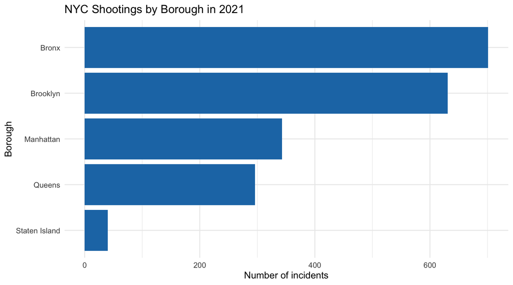

```r
ggplot(borough_summary, aes(x = reorder(boro, n), y = n)) +
  geom_col(fill = "#1f78b4") +
  coord_flip() +
  scale_y_continuous(labels = scales::label_comma()) +
  labs(
    title = "NYC Shootings by Borough in 2021",
    x = "Borough",
    y = "Number of incidents"
  ) +
  theme_minimal(base_size = 12)
```

The Bronx stands out clearly in the chart. Shootings were not spread evenly across the city, and some neighborhoods carried much more of the burden than others.

## Shootings by Time of Day

The time pattern shows that shootings were most common late at night. The highest counts appear around 11 PM, with high totals continuing through the nearby overnight hours.

```r
hourly_summary <- shootings %>%
  filter(!is.na(hour)) %>%
  count(hour, sort = FALSE)

knitr::kable(hourly_summary)
```

| hour | n |
| --- | --- |
| 0 | 145 |
| 1 | 117 |
| 2 | 105 |
| 3 | 80 |
| 4 | 82 |
| 5 | 31 |
| 6 | 31 |
| 7 | 24 |
| 8 | 16 |
| 9 | 22 |
| 10 | 25 |
| 11 | 30 |
| 12 | 47 |
| 13 | 56 |
| 14 | 48 |
| 15 | 84 |
| 16 | 94 |
| 17 | 101 |
| 18 | 85 |
| 19 | 129 |
| 20 | 155 |
| 21 | 142 |
| 22 | 168 |
| 23 | 194 |

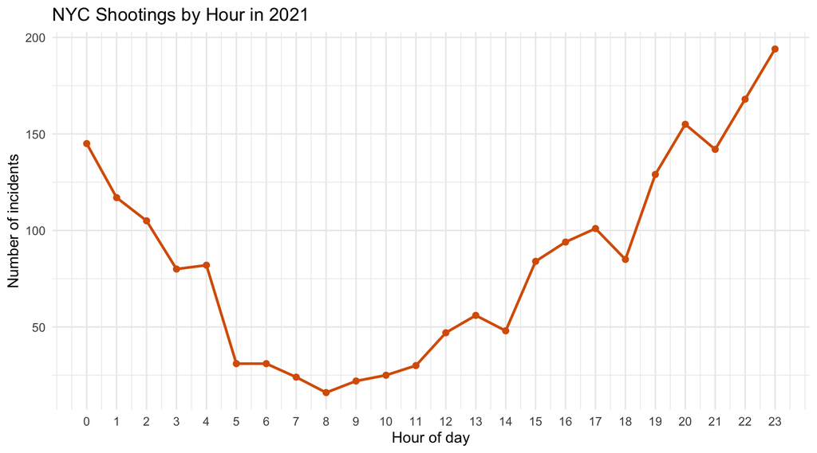

```r
ggplot(hourly_summary, aes(x = hour, y = n)) +
  geom_line(color = "#d95f02", size = 1) +
  geom_point(color = "#d95f02", size = 2) +
  scale_x_continuous(breaks = 0:23) +
  scale_y_continuous(labels = scales::label_comma()) +
  labs(
    title = "NYC Shootings by Hour in 2021",
    x = "Hour of day",
    y = "Number of incidents"
  ) +
  theme_minimal(base_size = 12)
```

This is one of the clearest patterns in the data. Many incidents happened when the city was quieter and visibility was lower.

## Shootings by Reported Location

The location descriptions show that many incidents were reported in public housing and apartment buildings. That suggests a large share of shootings happened in residential spaces, not only in open public areas.

```r
location_summary <- shootings %>%
  filter(!is.na(location_desc)) %>%
  count(location_desc, sort = TRUE)

knitr::kable(head(location_summary, 10))
```

| location_desc | n |
| --- | --- |
| MULTI DWELL - PUBLIC HOUS | 319 |
| MULTI DWELL - APT BUILD | 111 |
| GROCERY/BODEGA | 48 |
| PVT HOUSE | 36 |
| COMMERCIAL BLDG | 31 |
| BAR/NIGHT CLUB | 26 |
| HOSPITAL | 9 |
| GAS STATION | 8 |
| HOTEL/MOTEL | 8 |
| RESTAURANT/DINER | 6 |

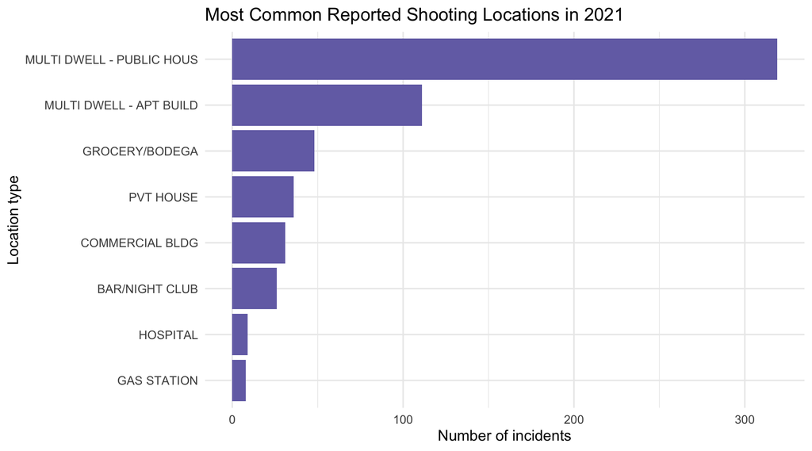

```r
ggplot(head(location_summary, 8), aes(x = reorder(location_desc, n), y = n)) +
  geom_col(fill = "#7570b3") +
  coord_flip() +
  scale_y_continuous(labels = scales::label_comma()) +
  labs(
    title = "Most Common Reported Shooting Locations in 2021",
    x = "Location type",
    y = "Number of incidents"
  ) +
  theme_minimal(base_size = 12)
```

Public housing developments and apartment buildings appear most often in the location field. That fits the broader picture of shootings being concentrated in residential parts of the city.

## Victim and Perpetrator Combinations

Looking across borough, victim race, perpetrator race, and age groups together helps show which combinations appeared most often in the records with more complete information.

```r
incident_combinations <- shootings %>%
  filter(
    !is.na(boro),
    !is.na(vic_race),
    !is.na(vic_age_group),
    !is.na(perp_race),
    !is.na(perp_age_group)
  ) %>%
  count(boro, perp_race, vic_race, perp_age_group, vic_age_group, sort = TRUE)

knitr::kable(head(incident_combinations, 10))
```

| boro | perp_race | vic_race | perp_age_group | vic_age_group | n |
| --- | --- | --- | --- | --- | --- |
| Bronx | BLACK | BLACK | 25-44 | 25-44 | 58 |
| Brooklyn | BLACK | BLACK | 25-44 | 25-44 | 53 |
| Queens | BLACK | BLACK | 25-44 | 25-44 | 32 |
| Manhattan | BLACK | BLACK | 25-44 | 25-44 | 28 |
| Brooklyn | BLACK | BLACK | 18-24 | 18-24 | 24 |
| Bronx | BLACK | BLACK | 18-24 | 25-44 | 22 |
| Manhattan | BLACK | BLACK | 18-24 | 25-44 | 21 |
| Brooklyn | BLACK | BLACK | 25-44 | 18-24 | 20 |
| Bronx | BLACK | BLACK | 18-24 | 18-24 | 17 |
| Bronx | BLACK | BLACK | 25-44 | 18-24 | 17 |

These combined summaries show repeated patterns in the neighborhoods most affected by shootings. They suggest the issue is tied to place and circumstance, not just isolated incidents.

## Conclusion

The data shows a few clear patterns. The Bronx had the highest number of incidents, shootings were most common late at night, and many were reported in public housing and apartment buildings. In the available demographic records, Black men between 25 and 44 appeared most often among both perpetrators and victims.

These patterns suggest the problem is closely tied to neighborhood conditions and to the environments in which people live. Poverty, education, housing conditions, and long-term disinvestment are more useful ways to think about the violence than simple demographic labels alone. The value of the data is that it helps track where the violence is concentrated and can support better decisions about prevention and community investment.